# EDA - Covariation

D. Howell

9/14/2020

In the last class we started talking about variation and visualizing the distribution of values within a single variable. To recap for just a second:

- we established some ways to plot a probability density function for continuous variables.
  - A PDF is a line where the x axis is the range values in your variable, and the y axis represents it’s level of frequency in the variable. In other words, the point on the x axis where the line reaches its peak is the value that occurs the most in your variable, and the lowest parts of the line are the values that occur the least.
  - PDF’s can be plotted in R using geom_freqpoly or geom_histogram (see the notes from the Variation lecture for some code examples).
- We also talked about how to visualize variance in a categorical variable.
  - Really the only way to do this is with a bar plot, or some other visualization where one axis lists each of the possible categories of the column, and the other axis is the number of times that category occurs in the variable.

Now, to quote directly from the book:

> If variation describes the behavior within a variable, covariation describes the behavior between variables. Covariation is the tendency for the values of two or more variables to vary together in a related way.

Covariation is important to know about within your data, because

- It gives you a deeper level of understanding, beyond just the individual behaviours of single variables
- If there is covariance between two of your variables, that has implications to the type of model you would choose for your analysis (if you are intending to model)

Plotting covariation means that instead of visualizing the frequency of each value within the column/variable, visualizing covariation plots two variables against each other. But… what does covariance between two variables look like? And what do you do when the two variables are different types?

These questions necessitate different solutions per different case:

- Exploring covariance between a categorical variable and a continuous variable
- Between two categorical variables
- And between two continuous variables

### Categorical vs. Continuous

Let’s take the flights data set that we looked at in the previous class. We start by copying the code from that class to recreate the top 5 destinations data set. Last time we visualized the the overall distribution of air times and found something weird looking. Plotted again here:

```r
library(nycflights13)
library(ggplot2)
library(dplyr)

df <- flights

top5_dest <- head(
  df %>%
    group_by(dest) %>%
    summarise(count = n()) %>%
    arrange(desc(count))
  ,5
)
df_top5 <- df[df$dest %in% top5_dest$dest,]

str(df_top5)
```

```
## Classes 'tbl_df', 'tbl' and 'data.frame':    80262 obs. of  19 variables:
##  $ year          : int  2013 2013 2013 2013 2013 2013 2013 2013 2013 2013 ...
##  $ month         : int  1 1 1 1 1 1 1 1 1 1 ...
##  $ day           : int  1 1 1 1 1 1 1 1 1 1 ...
##  $ dep_time      : int  554 554 557 558 558 559 600 606 608 615 ...
##  $ sched_dep_time: int  600 558 600 600 600 559 600 610 600 615 ...
##  $ dep_delay     : num  -6 -4 -3 -2 -2 0 0 -4 8 0 ...
##  $ arr_time      : int  812 740 838 753 924 702 837 837 807 833 ...
##  $ sched_arr_time: int  837 728 846 745 917 706 825 845 735 842 ...
##  $ arr_delay     : num  -25 12 -8 8 7 -4 12 -8 32 -9 ...
##  $ carrier       : chr  "DL" "UA" "B6" "AA" ...
##  $ flight        : int  461 1696 79 301 194 1806 4650 1743 3768 575 ...
##  $ tailnum       : chr  "N668DN" "N39463" "N593JB" "N3ALAA" ...
##  $ origin        : chr  "LGA" "EWR" "JFK" "LGA" ...
##  $ dest          : chr  "ATL" "ORD" "MCO" "ORD" ...
##  $ air_time      : num  116 150 140 138 345 44 134 128 139 120 ...
##  $ distance      : num  762 719 944 733 2475 ...
##  $ hour          : num  6 5 6 6 6 5 6 6 6 6 ...
##  $ minute        : num  0 58 0 0 0 59 0 10 0 15 ...
##  $ time_hour     : POSIXct, format: "2013-01-01 06:00:00" "2013-01-01 05:00:00" ...
```

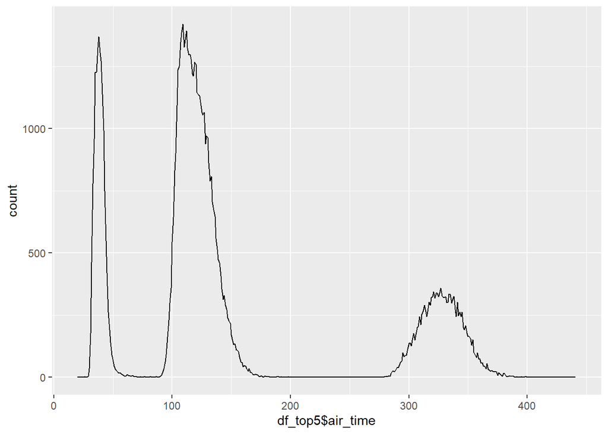

```r
ggplot(df_top5,aes(df_top5$air_time)) +
  geom_freqpoly( binwidth = 1)
```

Maybe if we visualize the covariance between the flight times to different destinations, that will give us some insight. When trying to visualize covariance between a continuous and a categorical variable, you have multiple otions, but the best one is to use the frequency polygon `geom_freqpoly()` and tell it to split the continuous distributions up by the categories of your discrete variable (usually this is done by setting the `color` argument to the discrete variable, and R plots different colors of lines per category).

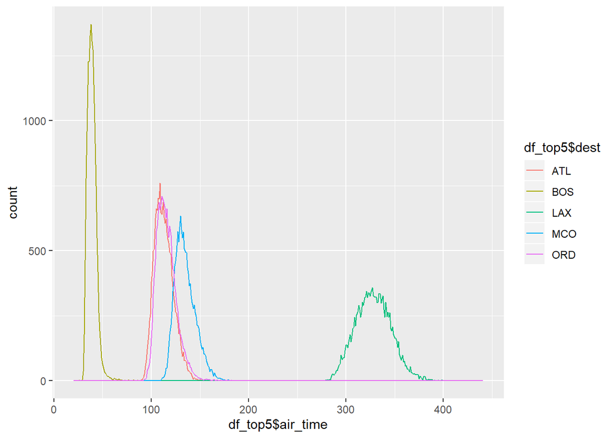

```r
ggplot(df_top5) +
  geom_freqpoly(aes(x=df_top5$air_time,color = df_top5$dest), binwidth=1)
```

Definitely helped! Now we realize that all the humps in the first distribution represented different destinations.

Keep in mind that we are visualizing the distribution of flights **to** these airports. What do the corresponding graphs for the **from** airports look like? Let’s copy and paste the above code and just change it for the origin column instead of dest.

In R, you can type `Ctrl/Command + F` to pull up the find/replace tool. Once you paste your code, just put `dest` in the find box and `origin` in the replace box and it will be easy to change the code that way.

```r
df <- flights

top5_origin <- head(
  df %>%
    group_by(origin) %>%
    summarise(count = n()) %>%
    arrange(desc(count))
  ,5
)
df_top5 <- df[df$origin %in% top5_origin$origin,]

str(df_top5)
```

```
## Classes 'tbl_df', 'tbl' and 'data.frame':    336776 obs. of  19 variables:
##  $ year          : int  2013 2013 2013 2013 2013 2013 2013 2013 2013 2013 ...
##  $ month         : int  1 1 1 1 1 1 1 1 1 1 ...
##  $ day           : int  1 1 1 1 1 1 1 1 1 1 ...
##  $ dep_time      : int  517 533 542 544 554 554 555 557 557 558 ...
##  $ sched_dep_time: int  515 529 540 545 600 558 600 600 600 600 ...
##  $ dep_delay     : num  2 4 2 -1 -6 -4 -5 -3 -3 -2 ...
##  $ arr_time      : int  830 850 923 1004 812 740 913 709 838 753 ...
##  $ sched_arr_time: int  819 830 850 1022 837 728 854 723 846 745 ...
##  $ arr_delay     : num  11 20 33 -18 -25 12 19 -14 -8 8 ...
##  $ carrier       : chr  "UA" "UA" "AA" "B6" ...
##  $ flight        : int  1545 1714 1141 725 461 1696 507 5708 79 301 ...
##  $ tailnum       : chr  "N14228" "N24211" "N619AA" "N804JB" ...
##  $ origin        : chr  "EWR" "LGA" "JFK" "JFK" ...
##  $ dest          : chr  "IAH" "IAH" "MIA" "BQN" ...
##  $ air_time      : num  227 227 160 183 116 150 158 53 140 138 ...
##  $ distance      : num  1400 1416 1089 1576 762 ...
##  $ hour          : num  5 5 5 5 6 5 6 6 6 6 ...
##  $ minute        : num  15 29 40 45 0 58 0 0 0 0 ...
##  $ time_hour     : POSIXct, format: "2013-01-01 05:00:00" "2013-01-01 05:00:00" ...
```

So, we notice something strange here, too. Why does the new `df_top5` not drop any rows from the original data set? They have the same number! It’s as if R is telling us that either we made a mistake, or the top 5 origins make up the whole data set. We can use the `unique()` function to figure out which three airports are in the origin column.

```r
unique(df_top5$origin)
```

```
## [1] "EWR" "LGA" "JFK"
```

There are only three origins! I guess the name `df_top5` is deceptive now. Oh well, we already pasted our code and it will work no matter what the name of the object is (as long as the name is consistent). Before we finish this analysis, it would be a good idea to go back and change the name of the object to `df_top3`, just so it isn’t confusing if/when someone else wants to read through your code, or if you need to come back to your code and you’ve forgotten why there aren’t 5 origins in the so called “top 5”.

I happen to know that LGA stands for Laguardia and JFK stands for John F. Kennedy, both of which are airports in New York City. A quick Google search tells me that EWR is the code for the Newark airport, which is also in NYC… Hold on a second… This data set appears to only show flights from the three major NYC airports. Now the package name `nycflights13` that this data set comes from makes more sense: it’s flights from NYC in the year 2013!

So when we visualized the top 5`dest` distributions above, the reason the peaks were so distinct is that they all had similar starting points. And maybe we can presume that ORD and ATL are roughly the same distance from NYC because those two peaks where almost indistinguishable. Let’s Google it.

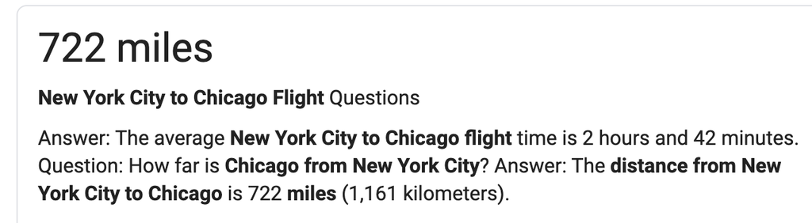

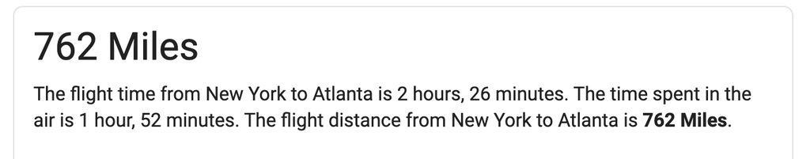

Nice! It’s weird that the flight times are different on Google, but that isn’t reflected in our data, and it doesn’t make sense given that the distances are almost the same.

Anyway, let’s back out of that rabbit hole and visualize our distributions for the origin column. Now that we know all the origins are in the same geographical location and the destinations are not, we may expect there to be less distinction between these distributions, unless perhaps, the three airports tend to fly mostly to different locations than the other three…

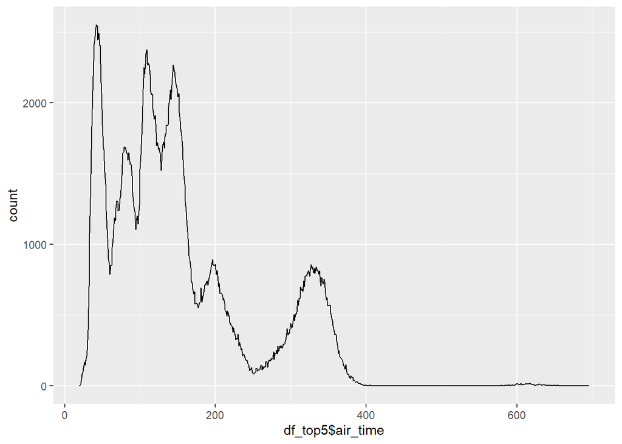

```r
ggplot(df_top5,aes(df_top5$air_time)) +
  geom_freqpoly( binwidth = 1)
```

There are still some distinct peaks in this distribution, which might be because, as we discovered earlier when we drilled down to the top 5 destinations, 80,000 out 330,000 (almost 1/4) of the observations are in the top 5 list.

Let’s plot the covariance to see if there is any distinction among the three origins.

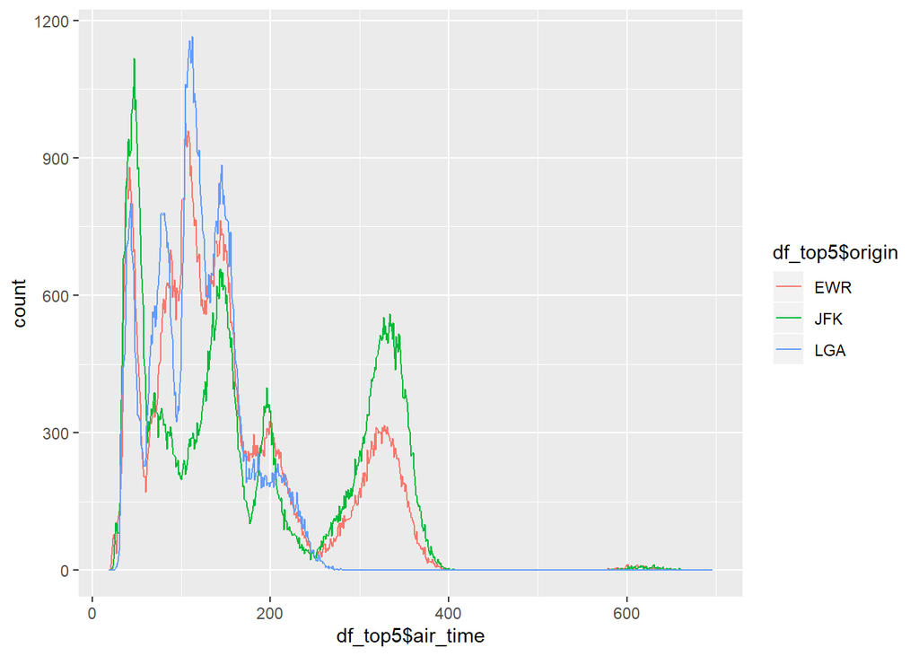

```r
ggplot(df_top5) +
  geom_freqpoly(aes(x=df_top5$air_time,color = df_top5$origin), binwidth=1)
```

Maybe… it’s sort of hard to tell. JFK sort of seems to be doing its own thing. Let’s facet these plots so that they appear next to each other, but separated.

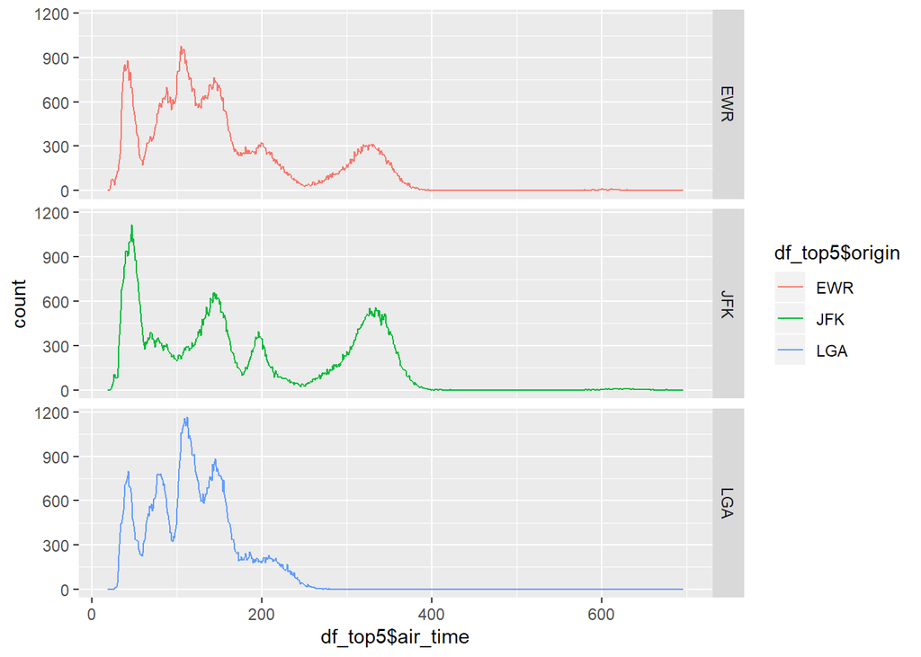

```r
ggplot(df_top5) +
  geom_freqpoly(aes(x=df_top5$air_time,color = df_top5$origin), binwidth=1) +
  facet_grid(rows = vars(df_top5$origin))
```

Does Laguardia not have a direct flight to LAX? We can be pretty sure from the distributions we’ve already seen, that the big hump around 325 minutes of airtime is flights from NYC to LA, and LGA appears to be totally flat…

I googled around this phenomenon to try to find an answer. See [this article from CNN in 2015.](https://money.cnn.com/2015/02/26/news/companies/laguardia-flights/index.html)

A couple quotes from the article:

- “LaGuardia has had a 1,500-mile restriction on most flights to and from the airport for more than 30 years. For travelers going to the West Coast, Las Vegas or Phoenix, that meant you have to fly through John F. Kennedy or Newark Liberty airports.”
- “The rule came about because the Port Authority wanted to encourage airlines to fly in and out of JFK and Newark airports at a time when LaGuardia was already at capacity.”

So much information from just one type of plot! Let’s get into the other two scenarios for plotting covariance.

### Two Continuous Variables

You have several options when you are plotting two continuous variables, but the best place to start is usually with a basic scatter plot. Let’s visualize the covariation between air_time and distance. It’s reasonable to think that these two variables would be related - unless for some reason commercial jets have a wide range of cruising speeds or something.

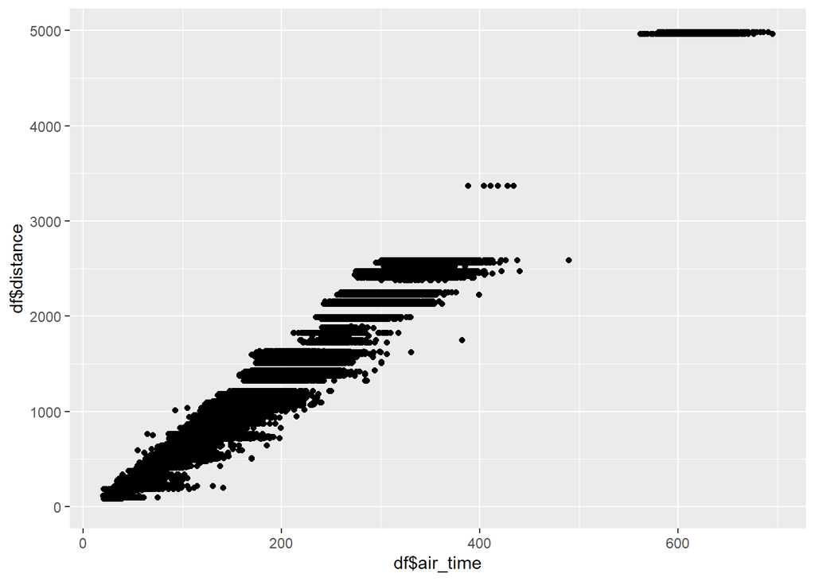

```r
ggplot(df) +
  geom_point(aes(x=df$air_time, y=df$distance))
```

This plot begins to confirm our suspicion that the two variables are related. However, we do have 330,000 points here, and they definitely seem to be getting overplotted. Let’s add the alpha argument to try to make it easier to see.

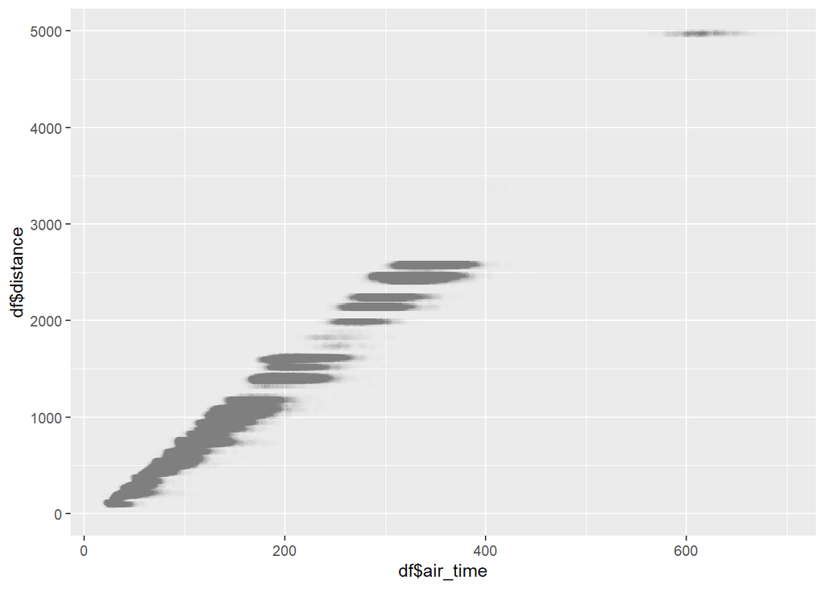

```r
ggplot(df) +
  geom_point(aes(x=df$air_time, y=df$distance), alpha = 1/250)
```

A common pairing to a plot like this is the `geom_smooth()` layer that you all have seen already. It adds a trendline to the graph that runs through the middle of all the points.

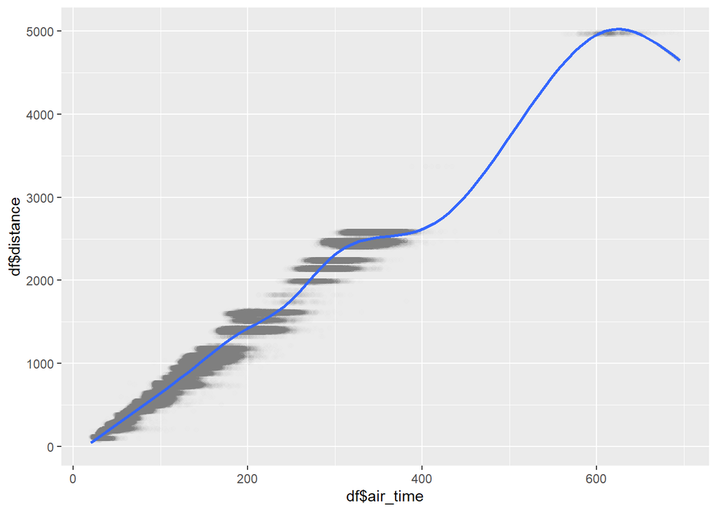

```r
ggplot(df) +
  geom_point(aes(x=df$air_time, y=df$distance), alpha = 1/250) +
  geom_smooth(aes(x=df$air_time, y=df$distance))
```

It’s worth explicitly laying out how we know that there is covariation by looking at this graph. These two variables show a high level of covariance because the scatter points stick closely around the trendline. In other words, we can be confident from this data that, whenever one of these variables increases or decreases, the other will likely do the same.

Another cool plot is the `geom_hex()` layer. It’s similar to a scatter plot, but it does a better job of showing different densities of points in a certain area. It is not a function of ggplot2 though, so you need to install the `hexbin` package first and load it into the R session.

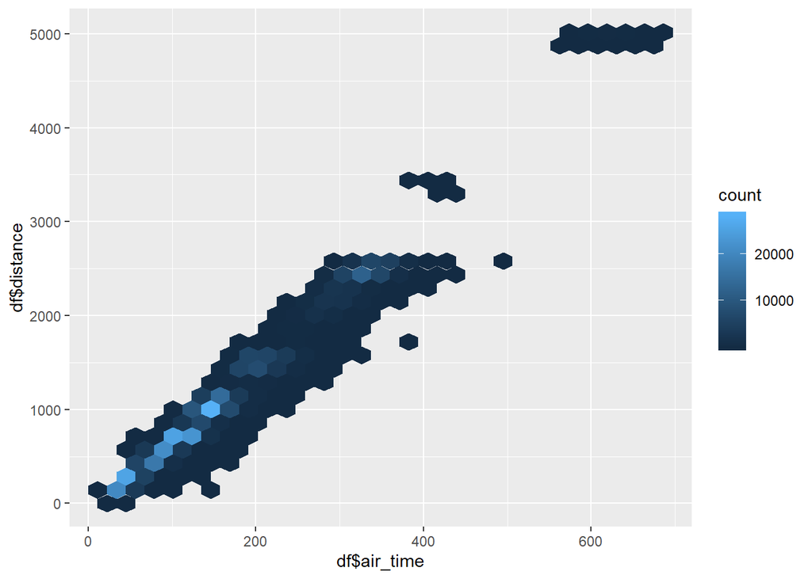

```r
#install.packages('hexbin')
library(hexbin)

ggplot(df) +
  geom_hex(aes(x=df$air_time, y=df$distance))
```

Two variables can have a lot of covariance in the opposite direction, too. In other words, covariance can also look like one variable consistently going down at the same rate as the other goes up.

### Two Categorical Variables

As you’ve seen before, plotting only categorical variables limits your visualizations to counts of each category. This is true when there are two categorical variables in the plot, too. Instead of having one axis for the categories and another for the counts, you have to use both axes for the variables and figure out a way to use the points to represent the count of times the two categories from different variables occur on a single row. There are a couple different tools you can use that are laid out in the book.

- You can use a scatter plot again, and size the dots based on the count of times the categories interact. `ggplot2` has a geom function made for this, called `geom_count()`. Let’s see what the top 5 destinations subset looks like in relation to the origins.

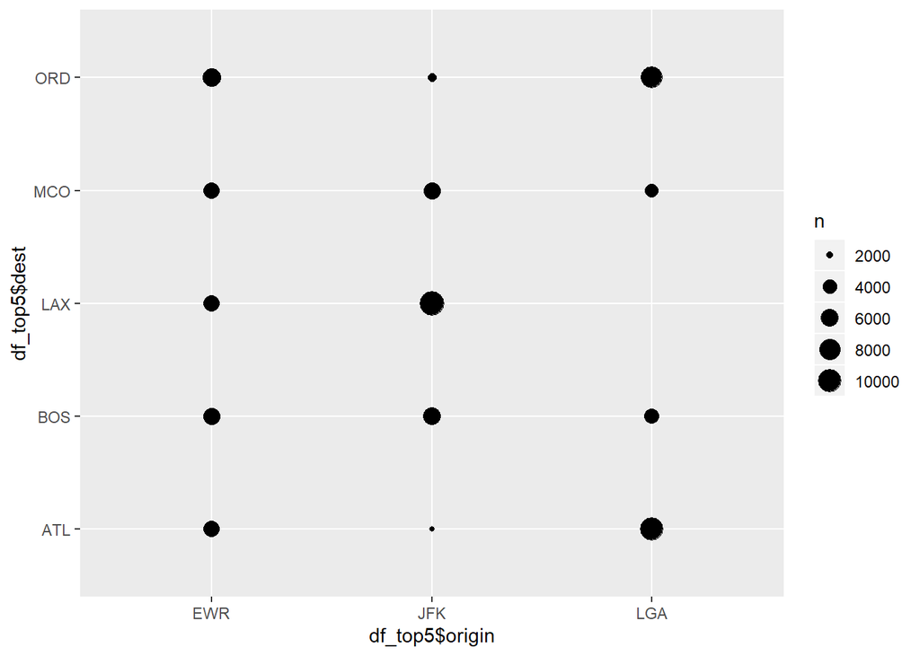

```r
# we need to run this code chunk again to make df_top5 the destinations dataset again.
top5_dest <- head(
  df %>%
    group_by(dest) %>%
    summarise(count = n()) %>%
    arrange(desc(count))
  ,5
)
df_top5 <- df[df$dest %in% top5_dest$dest,]

ggplot(df_top5) +
  geom_count(aes(x=df_top5$origin, y=df_top5$dest))
```

Sometimes these plots aren’t great because it’s difficult to distinguish the slight differences in the size of the dots, but this one works pretty well. This plot provides some extra confirmation directly from our data that there are no flights from LGA to LAX. I’m also interested in the symmetry of this plot. LGA and JFK are direct complements of each other, while EWR is sending roughly the same number of flights to each of the top 5 destinations.

The symmetry makes sense to me after reading the article linked above. It says that the NY Port Authority owns and controls all three airports, so they don’t have to compete with each other. Rather, they can designate different airports to serve different purposes. This plot makes me think that the symmetry is by design. Perhaps it would be less efficient for all the airports to send flights to each destination equally.

Another geom function that serves the same purpose, but is a little easier to view (in my opinion) is `geom_tile()`.

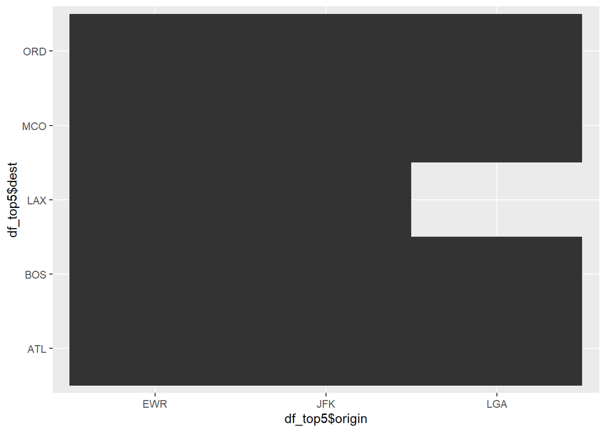

```r
ggplot(df_top5) +
  geom_tile(aes(x=df_top5$origin, y=df_top5$dest))
```

Looks like this function doesn’t count results automatically like `geom_count()` does. We need to transform the data before we can use this function effectively.

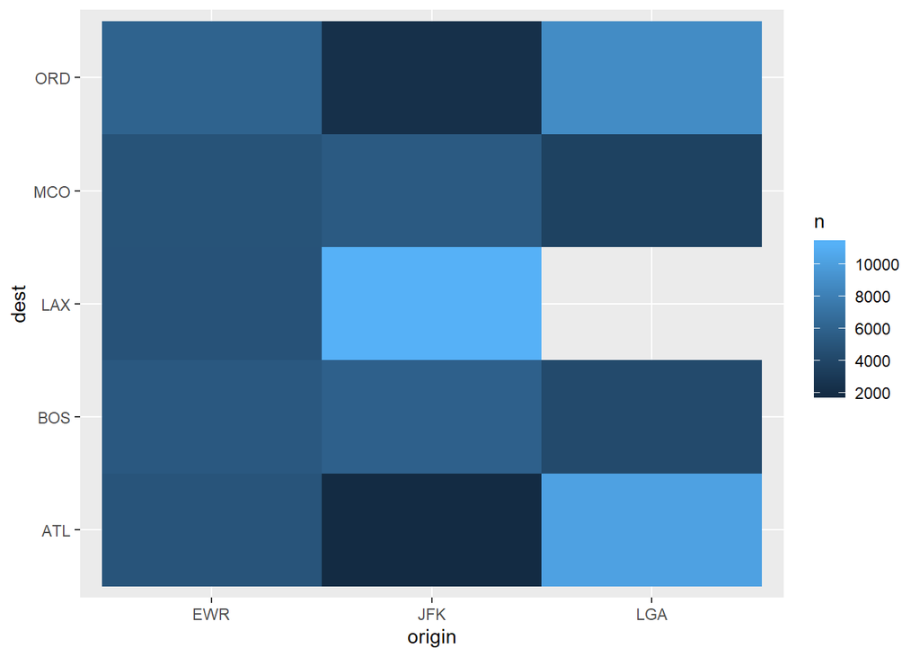

```r
df_top5 %>%
  count(dest, origin) %>%
  ggplot(mapping = aes(x = origin, y = dest)) +
    geom_tile(mapping = aes(fill = n))
```

I think this function gives a little more nuance. It’s easier for humans to distinguish slight differences in color than differences of size. I would rather use this one if I were giving a presentation, although it is slightly more work to create.

### Conclusions

Visualizing covariance is a necessary step towards understanding your data on a deeper level. You should definitely understand the variance within your variables first, but variance within variables alone does not give us any insight into the patterns and trends within your data.